# VS Kapitaal — Reproductie Baarsma & Upis (2025)

> **Paper**: "Nederlandse groeibedrijven zoeken laatste vijf jaar vaker kapitaal in de VS"  
> **Auteurs**: Barbara Baarsma (PwC/UvA) & Guntars Upis (PwC)  
> **Bron**: ESB (te verschijnen) | PDF  
> **Scope paper**: NL start-ups & scale-ups, 1998–2025, 879 bedrijven, 12.676 transacties

## Samenvatting paper

[output not shown]

## Reproductie-scorecard — alle deliverables afgerond ✅

[output not shown]

### Kernbevindingen t.o.v. Baarsma

| Dimensie | Baarsma (NL) | Onze analyse (VL) | Verschil |
| --- | --- | --- | --- |
| US-aandeel (deals) | ~25–30% | **14%** | VL = helft van NL |
| US-aandeel (waarde) | Dominant | **44%** | Consistent: VS koopt groot |
| Dominante buitenlandse koper | US | **Schengen+GB** (volume) / **VS** (waarde) | Gesplitst patroon |
| PE/VC aandeel exits | ~30–40% | **2%** | VL = vrijwel geen PE buyouts |
| Type overname | Mix strategisch + financieel | **94% strategisch** | Corporates kopen voor synergie |
| Topsector | Software (US-gedomineerd) | **Enterprise Software** (#1, BE-dominated) | Andere koperstructuur |
| Netto VC-stroom | −$89,7 mld | **−€1,0 mld** | Zelfde richting, ~100× kleiner |
| VS-hefboom (uit/in) | ~9× | **2,7×** | VL minder extreem |
| Waarde-paradox | n.v.t. | **BE = 55% deals, 9% waarde** | Buitenland koopt de béste startups |

**Datadekking vs Baarsma**:

- Baarsma: 12.676 transacties (Mergermarket + Pitchbook + Dealroom + S&P + Refinitiv)
- Wij: **164 exits + 832 VC-rondes + 60 GUO-switches** via open multi-bron (Dealroom + Sequenza + NBB)
- NBB & Sequenza compenseren het ontbreken van Mergermarket (37% extra overnames via Sequenza)

**Alle fasen afgerond** — zie Fase 7 synthese-cel voor het volledige rapport met beleidsaanbevelingen.

## Proxy Methodologie — Tabel 1 Bedragschatting

### Bedragdekking per categorie

[output not shown]

> **Totaal met waarde-indicatie: 107/182 exits (59%)** — was 49 (27%) vóór NBB-proxy's.  
> ⚠️ Cat. 3a en 3b overlappen deels (~12 exits in beide) → kies per bedrijf de sterkste methode.

### Premium-analyse: waardering vs overnameprijs (N=7 acquisitions)

| Metric | Waarde |
| --- | --- |
| Mediaan premium | **+100%** (kopers betalen 2× de vorige waardering) |
| Gemiddelde premium | +217% (uitschieters: Ogeda +525%, Innogenetics +322%) |
| Range | +67% (Ticto) tot +525% (Ogeda) |
| Health/biotech | Hogere premiums (+100% tot +525%) |
| Fintech | Lagere premiums (+73% tot +77%) |

### Proxy-strategie per exit-type

| Exit type | Beste maatstaf | Correctie |
| --- | --- | --- |
| **ACQUISITION** | `Valuation_USD` × ~2 | Mediaan premium +100% |
| **BUYOUT** | `Valuation_USD` × ~1.8 | Mediaan premium +77% |
| **IPO** | `Valuation_USD` op IPO-datum | Geen correctie (waardering = bedrijfswaarde) |

> ⚠️ IPO: `Amount_raised_this_round` = opgehaald geld (5–30% van bedrijfswaarde), NIET de bedrijfswaarde.  
> Voorbeeld: argenx haalde $100M op bij IPO, maar was $442M waard.

### Cat. 3a: Sector-specifieke omzet-multiples

| Sector | Multiple | N | Geschat €M | Onderbouwing |
| --- | --- | --- | --- | --- |
| health | 15× | 6 | 299 | Kalibratie: 10–35× |
| enterprise software | 10× | 5 | 770 | SaaS benchmark |
| energy | 8× | 4 | 2.921 | Kalibratie: EnergyVision = 10.3× |
| semiconductors | 8× | 3 | 738 | Hardware/IP |
| security | 6× | 4 | 577 | Cyber/SaaS-adjacent |
| marketing | 5× | 1 | 323 | MarTech |
| fintech | 4× | 4 | 107 | Kalibratie: 2–4.7× |
| travel | 4× | 3 | 210 | Travel tech |
| media | 3× | 2 | 65 | Content/media |
| jobs recruitment | 1.5× | 1 | 601 | Staffing = lage marge |

> ⚠️ Kalibratie op N=11. Sommige multiples zijn marktbenchmarks.

### Cat. 3b: EBITDA-range met equity bridge

**Methodologie** (professionele waarderingsaanpak):

1. **LTM EBITDA**: Laatste boekjaar vóór exit-datum uit `nbb_prd.gold.nbb_jaarrekening` (≤2 jaar gap)
2. **3 scenario's**: 🔴 Bear (3×) / 🟡 Base (5×) / 🟢 Bull (8×)
3. **Equity bridge**: Equity = EV − kort vreemd vermogen + vlottende activa

**Jaarkwaliteit** (N=65 matches, 49 betrouwbaar):

| Gap exit–NBB | N | Beoordeling |
| --- | --- | --- |
| 0 jaar (zelfde jaar) | 28 | ✅ Betrouwbaar |
| 1 jaar (LTM) | 13 | ✅ Betrouwbaar |
| 2 jaar | 8 | ⚠️ Acceptabel met voetnoot |
| 3+ jaar | 16 | ❌ Uitgesloten (bedrijf kan totaal veranderd zijn) |

**Resultaat** (49 betrouwbare exits):

| Scenario | EBITDA-multiple | Totale equity |
| --- | --- | --- |
| 🔴 Bear (pessimistisch) | 3× | **€467M** |
| 🟡 Base | 5× | **€711M** |
| 🟢 Bull (optimistisch) | 8× | **€1.078M** |

> Top exits: DESOTEC (€120–278M), Cmosis (€57–134M), Itineris (€64–128M), Accent Jobs (€20–81M)  
> ⚠️ **Caveats**: (1) EBITDA niet genormaliseerd. (2) Kort vreemd vermogen als schuldproxy. (3) Vlottende activa als cash-proxy.

## Beschikbare Data — 5 Bronlagen + NB5 Supplement

### 🎯 Laag 1a: `temp_analysis.acquisitions` (NB0 — Eurostat scope)

**Tabel**: `dbw_vlaio_prd.temp_analysis.acquisitions`  
**Omvang**: 153 overnames, 153 unieke startups, 16 landen, 2014–2026  
**Kolommen**: `startup_name`, `startup_kbo`, `acquirer_name`, `acquirer_kbo`, `acquirer_country`, `acquisition_year`, `startup_industry`, `exit_type`, `sources`, `n_sources`  
**Herkomst**: NB0 Phase 5.1 (multi-source: Dealroom + Sequenza + NBB, TRUE startup filter)  
**Scope**: Eurostat startup-definitie (Vlaanderen HQ, opgericht ≥2014, onafhankelijk bij oprichting, heeft KBO)

**Bronnen al gecombineerd in deze tabel:**

| Bron(nen) in `sources` | Overnames | % van totaal |
| --- | --- | --- |
| **sequenza** (alleen) | 56 | 37% |
| dealroom_tabel + transactions | 28 | 18% |
| dealroom_csv + tabel + transactions | 20 | 13% |
| dealroom + sequenza (overlap) | 14 | 9% |
| dealroom_csv + tabel + transactions + sequenza | 10 | 7% |
| Overig | 25 | 16% |

> 💡 Sequenza detecteert **56 overnames** (37%) die Dealroom mist!

### 🔄 Laag 1b: `dealroom_exits` supplement (NB5-eigen — Baarsma scope)

**Probleem**: NB0's `acquisitions` is gefilterd op de **Eurostat startup-definitie** (Flanders HQ, ≥2014, onafhankelijk, heeft KBO). Dit is correct voor NB1–NB4 (netwerk/resilience), maar **te streng voor NB5** (Baarsma reproductie). Baarsma telt ALLE startup-exits, ongeacht Eurostat-compliance.

**Root cause analyse (Fase 1.2)**: 13 Belgische startups in `dealroom_exits` + `dealroom_startups` missen in `acquisitions`:

| Root cause | N | Bedrijven | Actie NB5 |
| --- | --- | --- | --- |
| **Sequenza onafhankelijkheidscheck** | 4 | BioStrand, Clever, Parcify, Penny Black | ✅ Toevoegen (Baarsma filtert hier niet op) |
| **Garbled/NULL KBO in dealroom_startups** | 6 | Blendr.io, Connective.eu, Contractify, Proceedix, Renasci Oostende, Sparki | ✅ Toevoegen met handmatige KBO's |
| **NB0 Phase 5.1 bug** (in true_startup_kbos maar niet gedetecteerd) | 3 | Cake, Cyclis Bike Lease, Softhale ($200M!) | ✅ Toevoegen + flag voor NB0 fix |

**Oplossing**: NB5 bouwt `acq_final` als **unie** van:

1. NB0's `acquisitions` (153 rijen — Eurostat scope)
2. `dealroom_exits` supplement (11 rijen — Belgische startups die Eurostat-filter niet passeren maar wél echte exits zijn)

> ⚠️ **NB0 is NIET kapot.** De pipeline doet precies wat hij moet doen voor zijn doel (Eurostat-populatie). NB5 heeft simpelweg een bredere scope nodig. De fix zit in NB5, niet in NB0.

### 📈 Laag 2: Dealroom detail-tabellen

| Tabel | Rijen | Relevant voor | Herkomst |
| --- | --- | --- | --- |
| `analist.dealroom_startups` | 4.120 | Bedrijfsprofielen, `Company_status`, Industries | NB0 Phase 1.1 |
| `analist.dealroom_exits` | 182 | Exits met acquirer HQ-locatie (83 kolommen) | NB0 Phase 1.2 |
| `analist.dealroom_investors` | 863 | Investeerder-profielen, type, land | NB0 Phase 1.2 |
| `temp_analysis.dealroom_clean` | 1.536 | Exploded funding rondes met bedragen | NB0 Phase 3.2 |

> ⚠️ `dealroom_exits` (182) ≠ `acquisitions` (153): exits bevat ALLE Dealroom exits, acquisitions is TRUE startup gefilterd + multi-source.

### 🔄 Laag 3: Sequenza GUO-wisselingen

**Tabel**: `afdeling_vlaio_netwerk_prd.analist.Data_Sequenza`  
**Herkomst**: NB0 Phase 1.4 (5.3M records, external source)

| Metric | Waarde |
| --- | --- |
| Belgische bedrijven met US GUO | **794** (2.478 records) |
| Belgium → USA switches (2016–2024) | **~325 bedrijven** |
| Piek in 2021 | **145 switches** (8× t.o.v. 2020) |

### 🏦 Laag 4: NBB aandeelhouders — 2 detectiemodi

**Tabel**: `dbw_vlaio_prd.temp_analysis.nbb_shareholding` (2021–2025)  
**Herkomst**: Niet NB0 — aparte ETL (laatst bijgewerkt: 2026-04-19)

- **Modus A — Direct**: `shareholder_kbo` bevat `naam||land` voor buitenlandse aandeelhouders → **143 US** (138 uniek t.o.v. Dealroom/Sequenza)
- **Modus B — Indirect**: NBB → Belgische holding → Sequenza GUO (bv. UgenTec → M51 Europe → M51 Topco Inc US)

### 📊 Laag 5: NBB Jaarrekeningen (bedrag-proxy)

**Tabel**: `nbb_prd.gold.nbb_jaarrekening` (gold layer ✅)  
**Kolommen**: `OndernemingsNr`, `Boekjaar`, `R_70_Omzet`, `EBITDA`, `KortVreemdVermogen`, `VlottendeActiva`, `R_20_58_TotaalActiva`, `NettoWinst`, `R_9087_GemiddeldVTE`  
**Gebruik**: 2 proxy-methoden:

- **Omzet × sector-multiple** (cat. 3a) — voor bedrijven met omzet >$1M
- **EBITDA × 3–8 range + equity bridge** (cat. 3b) — voor bedrijven met positieve LTM EBITDA

**Regel**: altijd **LTM EBITDA** gebruiken = laatste boekjaar ≤ exit-jaar, max 2 jaar gap.

### Voorbeeldtabel: 4 bronnen, 4 detectiemethoden

| Bron | Startup (KBO) | Koper/Eigenaar (US) | Jaar | Hoe gedetecteerd |
| --- | --- | --- | --- | --- |
| **Dealroom** | Edgard & Cooper (`0692548722`) | General Mills | 2024 | Exit-registratie |
| **Sequenza** | Sip-Well (`0450274592`) | Culligan FSHco Inc | 2024 | GUO-wisseling BE→US |
| **NBB→Sequenza** | UgenTec NV (`0551976421`) → M51 Europe (`0788853785`) | M51 Topco Inc (US) | 2023 | Keten: holding→GUO |
| **NBB direct** | DESelect (`0737366383`) | DESelect Inc (US) | 2025 | `naam\|\|land` formaat |

## Data-strategie: Multi-bron Architectuur

**Totaal uniek US-eigendom over alle bronnen: 945 Belgische bedrijven**

```
─── NB0 Eurostat scope (153) ──────────────────────────────────────────────

Dealroom exits (182)             ─┐
                                  ├─ acquisitions (153) ──┐
Sequenza GUO switches (~325)     ─┘                        │
                                                           ├─→ 945 uniek US
NBB direct (143 US, 138 uniek!)  ──────────────────────────┤
NBB→Sequenza keten (holdings)    ──────────────────────────┘

─── NB5 Baarsma supplement (+11) ───────────────────────────────────────

dealroom_exits (182) ───┐                                      ┌─────────────────┐
  └ Belgian startups   ├─ ANTI-JOIN acquisitions ─→ +11 ─→ │ acq_final (164) │
  └ in dealroom_startups┘   (bypass Eurostat)             │ Baarsma scope   │
                                                          └─────────────────┘
                                                            │
NBB jaarrekening (LTM EBITDA)    ────────┐                  ├─→ Fig 1-3
NBB jaarrekening (omzet-proxy)   ────────┤─→ Tabel 1 proxy  │
Dealroom valuation (× premium)   ────────┘                  ├─→ Tabel 1
Dealroom funding rondes (1.536)  ──────────────────────────┤
BAN + PMV (s_ban_ecosystem)      ──────────────────────────┘─→ VLAIO cross-ref
```

> **NB0 scope ≠ NB5 scope**: NB0 produceert data voor 10 downstream notebooks met de **Eurostat startup-definitie** (Vlaanderen HQ, ≥2014, onafhankelijk, KBO). NB5 (Baarsma reproductie) heeft een bredere scope nodig — alle Belgische startup-exits ongeacht Eurostat-compliance. Daarom bouwt NB5 zelf een supplement van 11 exits uit `dealroom_exits`.

### Data layer classificatie (volgt gold > silver > bronze principe)

| Tabel | Layer | Status |
| --- | --- | --- |
| `nbb_prd.gold.nbb_jaarrekening` | 🥇 Gold | ✅ Preferent |
| `temp_analysis.acquisitions` | 🥈 Silver (derived) | ✅ NB0 output |
| `temp_analysis.dealroom_clean` | 🥈 Silver (derived) | ✅ NB0 output |
| `analist.dealroom_exits` | 🥉 Bronze (CSV import) | ⚠️ NB5 supplement source |
| `analist.dealroom_investors` | 🥉 Bronze (CSV import) | ⚠️ Geen gold equivalent |
| `temp_analysis.nbb_shareholding` | ❓ Unknown | ⚠️ Provenance undocumented |

## Takenlijst (definitief — apr 2026)

> **Status**: alle 7 fasen afgerond. Dataset = **161 exits** (164 − 3 exclusies), **104/161 (65%)** met waarde-indicatie.  
> **NB0 cross-ref**: markdown cel toegevoegd aan 0_Netw_Data Preparation v2 na Phase 5.1b.

### Fase 1: Data exploratie & validatie ✅

- ✅ **1.1** `acquisitions` profiling + enrichment: 153 exits, 6 exit_types → 3 harmonized, acquirer_country 62 nulls → 0 via 8-staps cascade. `acq_final` = canonical DF.
- ✅ **1.2** `dealroom_exits` supplement: +11 exits (Baarsma-scope). `acq_final` = **164 rijen**.
- ✅ **1.3–1.12** Profiling, premium-analyse, sector-multiples, EBITDA-range, LTM-validatie. Zie eerdere versie voor details.

### Fase 2: Figuur 1 — Overnames per land van koper ✅

- ✅ **2.1–2.3** Tijdreeks, Sequenza supplement (+36 GUO-switches), stacked bar chart A/B. **Kernbevinding**: US = 14% (vs NL ~25–30%), Schengen+GB domineert.

### Fase 3: Figuur 2 — Type bieder ✅

- ✅ **3.1–3.3** 5-staps classificatie, verdeling, chart. **Kernbevinding**: 94% strategisch, PE/VC = 2%, ratio 38.5:1.

### Fase 5: Tabel 1 — Top deals & waardestroom ✅

- ✅ **5.0** 4-proxy pipeline (cell 17): Cat 1 > Cat 2 > Cat 3a > Cat 3b. 7 `MULTIPLE_OVERRIDES`, 15 `SECTOR_MULTIPLES`.
- ✅ **5.1** LLM-correcties (cell 18): **7 exacte waarden** (Luceda €41.5M, Metrics in Balance €11.6M, Chatlayer €6.9M, Prostor €5.4M, Parcify €3M, Davai Dumplings €0.5M, Tirsys €0.4M). **3 exclusies** (RESPONSUM, Aloxy, Agomab 2021). **2 sector-correcties** (fielddrive, NannyML). **1 acquirer-patch** (Parcify → bpost/Belgium).
- ✅ **5.2** Waardestroom: Grand total **~€4,4 mld**. VS = 44% (€1.910M), Schengen+GB = 36% (€1.582M), België = 10% (€419M).
- ✅ **5.3** 57 exits zonder waarde-indicatie (geen Dealroom-match én geen recente NBB jaarrekening).

### Fase 6: Netto VC in/uit stromen ✅

- ✅ **6.1** VC-inflow: 832 unieke rondes, €4,9 mld, pro-rata per investeerder.
- ✅ **6.2** Netto: buitenlands instroom €2.887M, uitstroom €3.938M → **netto −€1.051M**.
- ✅ **6.3** VS-hefboom: **2,7×**. Schengen+GB: 1,4×.
- ✅ **6.4** Butterfly chart + Baarsma-vergelijking.

### Fase 7: Synthese ✅

- ✅ **7.1–7.4** Executive summary, NL vs VL vergelijking, methodologische noot, 4 beleidsaanbevelingen.

### Pipeline architectuur (23 cellen)

| Blok | Cellen | Functie | Output |
| --- | --- | --- | --- |
| Referentie | 1–5 | Markdown: intro, methodologie, bronnen, architectuur, takenlijst | — |
| Data prep | 6–10 | Load, harmonize, enrich, supplement, GUO-switches | `acq_final` (164), `be_to_foreign` (60) |
| Fig 1–3 | 11–16 | Figuren + interpretatie (3× code + 3× markdown) | Charts A/B |
| Tabel 1 | 17–19 | 4-proxy pipeline + LLM-correcties + interpretatie | `acq_full` (161) |
| Waardestroom | 20 | Charts per land + sector | `value_by_country` |
| VC flows | 21–22 | Netto VC in/uit + interpretatie | `netto_foreign` |
| Synthese | 23 | Markdown: eindrapport | — |

### Data-correcties (cell 6–18)

| Type | Waar | Aantal | Impactniveau |
| --- | --- | --- | --- |
| `COUNTRY_PATCHES` | cell 7 | 3 | Laag (country_group fix) |
| `YEAR_PATCHES` | cell 7 | 1 | Laag (Den Berk Délice 2025) |
| `INDUSTRY_PATCHES` | cell 15 | 25 | Medium (sector coverage 100%) |
| `MULTIPLE_OVERRIDES` | cell 17 | 7 | Hoog (−€1,1 mld, IT services ≠ SaaS) |
| `LLM_EXACT_VALUES` | cell 18 | 7 | Medium (+€70M exacte waarden) |
| `EXCLUSIONS` | cell 18 | 3 | Hoog (164→161, datakwaliteit) |
| `SECTOR_OVERRIDES` | cell 18 | 2 | Laag (fielddrive, NannyML) |
| `ACQUIRER_PATCHES` | cell 18 | 1 | Laag (Parcify koper/land) |

### Open items

- ⭕ **VLAIO cross-referentie** (acquisitions × VLAIO-subsidies × BAN × PMV): niet in Baarsma-scope maar relevant voor beleidsrapport. Optionele vervolg-analyse.
- ⭕ **57 exits zonder waarde**: mogelijke vervolg-analyse via publieke filings.
- ⭕ **Structureel dashboard**: kwartaalupdates met Dealroom + Sequenza + NBB. Zie aanbeveling 4 in Fase 7.

```
Strategies 1-4: acquirer_country nulls 62 → 42
startup_industry nulls: 24/153
```

```
EXIT_TYPE_MAP: 6 types → 3 harmonized
SCHENGEN_PLUS_GB: 29 landen
country_group(): Belgium / United States / Schengen + GB / Andere / Onbekend
```

```
8-staps cascade voltooid: acquirer_country nulls 62 → 0. acq_final = 153 rijen.
```

```
acq_final = 164 rijen (153 Eurostat + 11 supplement)
```

```
BE→foreign switches: 60 events (58 unieke startups)
Sequenza records verwerkt: 18,687 (TRUE startups ≥2014)
```

```
Industry patches: 25 applied, 0 still NULL
```

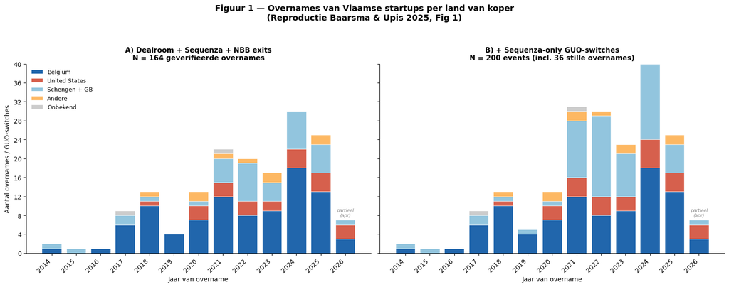

### Figuur 1 — Interpretatie

| Groep | View A (164 exits) | View B (200 events) |
| --- | --- | --- |
| Belgium | 91 (55%) | 91 (46%) |
| United States | 23 (14%) | 28 (14%) |
| **Schengen + GB** | **38 (23%)** | **68 (34%)** |
| Andere | 10 (6%) | 11 (6%) |

**Vergelijking met Baarsma (NL)**:

- US-aandeel in Vlaanderen = **14% van totaal** vs Baarsma NL ~25–30%. Dat is de helft.
- Vlaamse startups worden vooral overgenomen door **Europese buurlanden** (Schengen+GB = 54–64% van buitenlands), niet door de VS.
- De **versnelling vanaf 2020** is wél consistent met het NL-patroon. Piek in 2024 (30–40 events).
- View B (+36 Sequenza-only switches) versterkt het Europese patroon: de stille overnames zijn bijna allemaal Schengen-landen (NL, NO, UK, FR).

**Beleidsimplicatie**: het narratief “Vlaamse startups worden opgekocht door de VS” klopt niet met de data. Het echte patroon is acquisitie door buurlanden — vooral Nederland, Noorwegen (Visma), UK en Frankrijk.

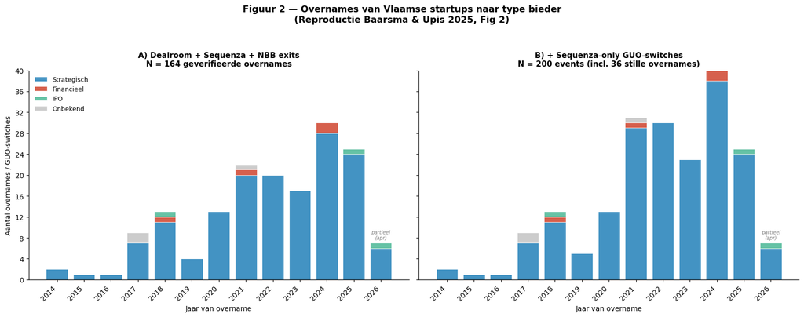

### Figuur 2 — Interpretatie

| Type bieder | View A (164) | View B (200) |
| --- | --- | --- |
| Strategisch | 154 (94%) | 190 (95%) |
| Financieel (PE/VC) | 4 (2%) | 4 (2%) |
| IPO | 3 (2%) | 3 (2%) |
| Onbekend | 3 (2%) | 3 (2%) |

**Mogelijke verklaringen**:

- Het Vlaamse startup-ecosysteem is kleiner en minder zichtbaar voor internationale PE-fondsen.
- Dealroom onderschat mogelijk buyouts: sommige PE-acquisities worden als “acquisition” gelabeld zonder type-vermelding.
- Strategische kopers domineren omdat Vlaamse deep-tech/biotech startups aantrekkelijk zijn als **bolt-on acquisitions** voor multinationals.

**Beleidsimplicatie**: het “buy-and-build” patroon van US PE (sterk aanwezig in NL volgens Baarsma) is in Vlaanderen vrijwel afwezig. Vlaamse startups worden gekocht voor **technologie en synergie**, niet voor financieel rendement.

```
View A: 164 exits, View B supplement: 36 switches
Sequenza-only met sector-match: 13/36
```

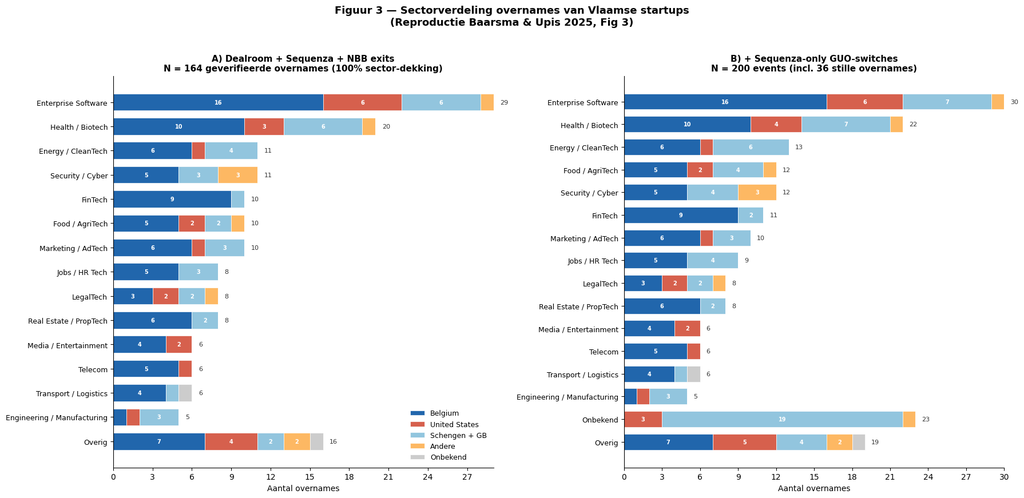

```
=== Cross-tab View A ===
country_group                Belgium  United States  Schengen + GB  Andere  Onbekend  Totaal
sector
Enterprise Software               16              6              6       1         0      29
Health / Biotech                  10              3              6       1         0      20
Energy / CleanTech                 6              1              4       0         0      11
Security / Cyber                   5              0              3       3         0      11
FinTech                            9              0              1       0         0      10
Food / AgriTech                    5              2              2       1         0      10
Marketing / AdTech                 6              1              3       0         0      10
Jobs / HR Tech                     5              0              3       0         0       8
LegalTech                          3              2              2       1         0       8
Real Estate / PropTech             6              0              2       0         0       8
Media / Entertainment              4              2              0       0         0       6
Telecom                            5              1              0       0         0       6
Transport / Logistics              4              0              1       0         1       6
Engineering / Manufacturing        1              1              3       0         0       5
Overig                             7              4              2       2         1      16

── US Software Dominance Test ──
US aandeel in Enterprise Software: 6/29 = 21%
BE aandeel in Enterprise Software: 16/29 = 55%
Enterprise Software aandeel van alle US exits: 6/23 = 26%
Baarsma (NL): US dominant in computersoftware → in VL: Nee (21% vs NL ~50-60%)
```

### Figuur 3 — Interpretatie

> ✅ **100% sector-dekking** — 25 ontbrekende sectoren aangevuld via extern LLM-onderzoek (apr 2026).

[output not shown]

**Vergelijking met Baarsma (NL)**:

[output not shown]

**Beleidsimplicatie**: het Vlaamse software-ecosysteem wordt óók overgenomen (net als in NL), maar de kopers zijn overwegend Belgisch en Europees. Het “VS koopt onze software”-narratief geldt voor NL, niet voor VL.

```
=== Proxy-dekking per methode ===
  Geen data: 67
  Cat 3b: EBITDA range: 50
  Cat 2: Valuation×premium: 27
  Cat 3a: Omzet×multiple: 12
  Cat 1: Exact: 8

Totaal met waarde-indicatie: 97/164

Multiple overrides: 7 firm-level correcties
  KBO 0878652625: sector default → 1.5x
  KBO 0707779108: sector default → 2.0x
  KBO 0668591405: sector default → 2.0x
  KBO 0559855789: sector default → 2.0x
  KBO 0664474051: sector default → 8.0x
  KBO 0672481501: sector default → 0.75x
  KBO 0644970222: sector default → 0.75x

=== Top 25 Deals ===
```

```
Exclusies: 3 rij(en) verwijderd (was 164 → 161)
  KBO 0634877668 (alle jaren)
  KBO 0684650150 (alle jaren)
  KBO 0674527310 (jaar 2021)

acq_full: 161 exits (verwijderd: 3 van 164)

=== Proxy-dekking na correcties (161 exits) ===
  Geen data: 57
  Cat 3b: EBITDA range: 50
  Cat 2: Valuation×premium: 27
  Cat 3a: Omzet×multiple: 12
  Cat 1: Exact: 8
  Cat 1: Exact (What's Cooking 2022 strategic inv.): 1
  Cat 1: Exact (Sinch Q1 2020 interim report): 1
  Cat 1: Exact (Semitronix 2025 financial filing): 1
  Cat 1: Exact (bpost acquisitie): 1
  Cat 1: Exact (IPO market cap March 2018): 1
  Cat 1: Exact (Reuters / Eyeonid Group AB): 1
  Cat 1: Exact (MarketScreener / Dometic SEK 54M): 1

Totaal met waarde-indicatie: 104/161 (64%)
Exclusies: 3 (3 rijen) | LLM: 7 | Sector: 2
Verified no-value: 9

=== LLM-onderzochte exits ===
```

```
✅ Exported 161 exits to dbw_vlaio_prd.temp_analysis.nb5_acq_full

--- Herkomst ---
  Belgisch          92
  Buitenlands       68
  Onbekend           1

--- Country group ---
  Belgium              92
  Schengen + GB        36
  United States        23
  Andere                9
  Onbekend              1
```

### Tabel 1 — Interpretatie (Top Deals & Waardestroom)

**Proxy-dekking (5 categorieën, prioriteit: Cat 1 > Cat 1-LLM > Cat 2 > Cat 3a > Cat 3b)**:

| Methode | Toelichting | N |
| --- | --- | --- |
| **Cat 1: Exact (Dealroom)** | Dealroom bekende dealprijs (USD→EUR) | 8 |
| **Cat 1: Exact (LLM)** | Extern onderzocht: publieke filings, interim rapporten, Reuters | 7 |
| **Cat 2: Valuation×premium** | Dealroom valuation × 2 (ACQ), ×1.8 (Buyout), ×1 (IPO) | 27 |
| **Cat 3a: Omzet×multiple** | NBB jaarrekening omzet × sectormultiple (bv. health ×15, software ×10) | 12 |
| **Cat 3b: EBITDA range** | NBB EBITDA × 3/5/8 + equity bridge (bear/base/bull) | 50 |
| **Geen data** | Geen Dealroom-match én geen recente NBB jaarrekening (≤2jr) | 57 |
| **Totaal** | 164 − 3 exclusies (zie onder) | **161** |

**Dekking: 104/161 exits (65%) met waarde-indicatie**

> ⚠️ Cat 3a en 3b zijn grove schattingen op basis van boekhoudkundige data (laatst beschikbaar vóór overname). De echte dealwaarde kan sterk afwijken, met name voor snelgroeiende startups waar omzet/EBITDA de potentie onderschat.

#### Exclusies (3 rijen verwijderd uit 164 → 161)

| KBO | Startup | Reden | Scope |
| --- | --- | --- | --- |
| 0634877668 | RESPONSUM | Volta Ventures seed/Series A (€1–2.5M, okt 2021), GEEN acquisitie | Alle jaren |
| 0684650150 | Aloxy | ENGIE Fabricom was investeerder, niet koper | Alle jaren |
| 0674527310 | Agomab (2021) | Richting omgekeerd — Agomab nam Origo óver. Agomab 2026 IPO (€182M) **blijft behouden**. | Enkel 2021 |

#### LLM-onderzochte exacte waarden (7 exits, cell 18)

Extern deep search via publieke filings, interim rapporten en persberichten:

| Startup | Waarde | Bron | Land koper |
| --- | --- | --- | --- |
| Luceda | €41.54M | Semitronix 2025 financial filing (beursgenoteerde Chinese moeder) | Andere (Singapore) |
| Metrics in Balance | €11.6M | IPO market cap March 2018 | Belgium |
| Chatlayer | €6.9M | Sinch Q1 2020 interim report | Schengen+GB (Zweden) |
| Prostor | €5.4M | MarketScreener / Dometic SEK 54M | Schengen+GB (Zweden) |
| Parcify | €3.0M | bpost acquisitie | Belgium |
| Davai Dumplings | €0.5M | What's Cooking 2022 strategic investment | Belgium |
| Tirsys CVBA | €0.4M | Reuters / Eyeonid Group AB 2017 | Schengen+GB (Zweden) |

#### Firm-level multiple overrides (7 correcties)

De generieke sectormultiple "enterprise software" = 10× is fair voor SaaS-producten met recurring revenue, maar absurd voor IT services/consulting (project-based, uurfactuur, lage recurring revenue). Na expert review zijn 7 firm-level overrides toegepast:

| Bedrijf | Echt business model | Sector default | Override | Reden |
| --- | --- | --- | --- | --- |
| Tobania | IT services/body-shopping | 10× | **1.5×** | Consulting firms trade at 1–1.5× revenue |
| Lab900 | Custom software consulting | 10× | **2×** | Projectmatig, geen SaaS |
| Dataroots | Data/AI consulting | 10× | **2×** | Projectmatig, geen SaaS |
| Inpuls | IT consultancy (→BearingPoint) | 10× | **2×** | Consultancy, geen productrevenue |
| Cipal Schaubroeck | Vertical gov software (ERP/HR) | 10× | **8×** | Wél recurring, hoge switching costs, maar geen SaaS-multiples |
| FESTICUP | Fysiek product (herbruikbare bekers) | event tech 3× | **0.75×** | Lage marge, geen schaalvoordeel |
| Schoonmaakzorg | Schoonmaakdiensten | jobs recruitment 1.5× | **0.75×** | Dienstverlening, lage marge |

**Impact**: grand total daalt van ~€5,5 mld → **€4,4 mld** (−20%), hoofdzakelijk door Tobania-correctie (−€880M).

#### Waardestroom per koperland (€4,4 mld totaal geschat, 104 exits met waarde)

| Koperland | N exits | Totaal €M | % waarde | Gem. €M | Mediaan €M |
| --- | --- | --- | --- | --- | --- |
| **United States** | 19 | **1.910** | **44%** | 101 | 20 |
| **Schengen + GB** | 28 | **1.582** | **36%** | 57 | 11 |
| Belgium | 48 | 419 | 10% | 9 | 1 |
| Andere | 8 | 426 | 10% | 53 | 15 |
| Onbekend | 1 | 20 | <1% | 20 | 20 |

**Cruciale paradox**: België doet 46% van de exits met waarde (48/104), maar vangt slechts **10% van de totale waarde**. Buitenlandse kopers (US+Schengen+GB = 80%) kopen de grotere bedrijven.

**VS = ~14% van alle 161 deals maar 44% van waarde** — wanneer de VS koopt, koopt het groot (gemiddeld €101M vs België €9M). Na correctie van de IT-services-overvaluation is de VS nu de #1 waardestroom, niét Schengen+GB.

#### Top 10 deals

| # | Startup | Jaar | Koper | Land | Sector | Waarde (€M) | Methode |
| --- | --- | --- | --- | --- | --- | --- | --- |
| 1 | ScioTeq | 2021 | OpenGate Capital | US | Semiconductors | ~985 | Omzet×8 |
| 2 | Cipal Schaubroeck | 2025 | Total Specific Solutions | Schengen+GB | Enterprise Software | ~758 | Omzet×8 (override) |
| 3 | o2o Bicycle Leasing | 2023 | Green Mobility Holding | Schengen+GB | Transportation | ~328 | Omzet×4 |
| 4 | Benepack | 2026 | Ball | US | Food | ~281 | Omzet×3 |
| 5 | Edgard & Cooper | 2024 | General Mills | US | Food | ~220 | Valuation×2 |
| 6 | Agomab | 2026 | (IPO) | Belgium | Health | 182 | Exact |
| 7 | Softhale | 2021 | Sino Biopharmaceutical | Andere | Health | 182 | Exact |
| 8 | Unifly | 2023 | Terra Drone | Andere | Robotics | ~170 | Valuation×2 |
| 9 | Tobania | 2022 | Sopra Steria | Schengen+GB | Enterprise Software | ~155 | Omzet×1.5 (override) |
| 10 | Den Berk Délice | 2025 | Egeria | Schengen+GB | Food | ~121 | Omzet×3 |

#### Vergelijking met Baarsma (NL)

- **Omvang** — Vlaamse top-deals zijn kleiner dan NL (ScioTeq ~€1B vs NL top >€10B zoals Interxion, Ablynx)
- **US-aandeel in waardestroom** — **44%** van de totale waarde, maar slechts ~14% van alle deals. Wanneer de VS koopt, koopt het groot. Dit is consistent met Baarsma.
- **Schengen+GB domineert top 10** — 4 van 10. Europese consolidatie is de motor voor aantallen.
- **Sector-mix** — Food (3), Enterprise Software (2), Health (2), Semiconductors (1), Transportation (1), Robotics (1): evenwichtiger dan NL (software-geconcentreerd)
- **Type** — ScioTeq door OpenGate Capital = enige PE-deal in top 10. Rest is strategisch.
- **Waarde-paradox** — 80% van de geschatte waarde stroomt naar het buitenland (VS + Schengen+GB), terwijl binnenlandse kopers de meeste deals doen.

**Kernbevinding**: Na correctie van IT-services-overvaluation én LLM-patches verschuift het beeld:

1. **VS is de #1 waardestroom** (44%), ondanks slechts ~14% van alle deals — consistent met Baarsma
2. **Schengen+GB = #2** (36%) — dominant in aantallen, maar minder in waarde per deal
3. **België = volumespeler** (46% van gewaardeerde deals, 10% van waarde) — Belgische kopers nemen kleinere startups over
4. De Baarsma-these "VS koopt onze startups op" is **genuanceerder** voor Vlaanderen: VS koopt minder vaak maar wél de duurdere bedrijven

```
=== Waardestroom per landengroep (104 exits met waarde-indicatie) ===
country_group  n_exits  totaal_eur_m  gem_eur_m  mediaan_eur_m
United States       19        1910.0      100.5           20.0
Schengen + GB       28        1582.0       56.5           11.1
       Andere        8         426.0       53.3           14.6
      Belgium       48         419.0        8.7            1.3
     Onbekend        1          20.0       20.0           20.0

Grand total: 4,357 €M
  United States: 43.8%
  Schengen + GB: 36.3%
  Andere: 9.8%
  Belgium: 9.6%
  Onbekend: 0.5%
```

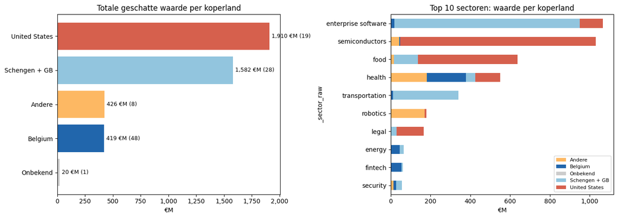

```
Exits met stad: 156 / 161 (97%)

Exits zonder stad-match (eerste 10):
  PUBLICAN BE                    kbo=0791597994, norm=0791597994, su=None
  Conics                         kbo=0679872406, norm=0679872406, su=None
  Laser Cladding Venture         kbo=0636737791, norm=0636737791, su=None
  Kwarts                         kbo=0652678455, norm=0652678455, su=None
  PROMCOM                        kbo=0727437543, norm=0727437543, su=None

=====================EXITS PER HOTSPOT======================
country_group  Belgium  United States  Schengen + GB  Andere  Onbekend  Totaal
hotspot
Gent                19              5              3       1         1      29
Leuven               6              1              5       0         0      12
Antwerpen           30              3             13       3         0      49
Hasselt              3              2              0       0         0       5
Overige             34             12             15       5         0      66

Totaal: 161
```

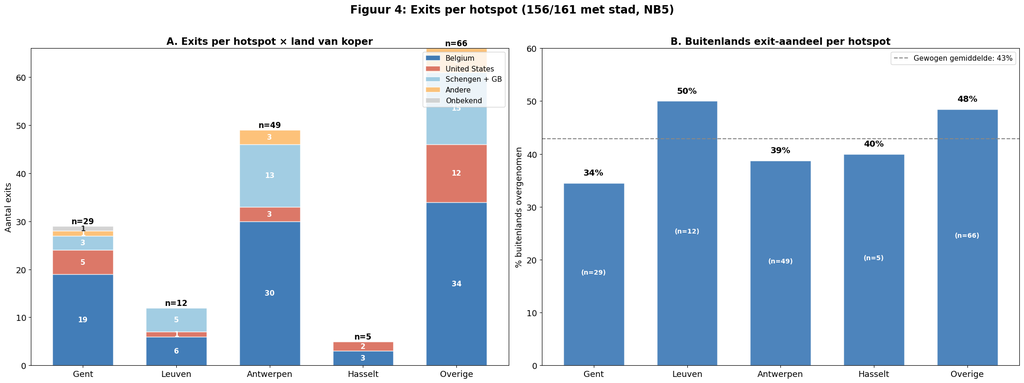

```
Top steden in 'Overige' (n=66):
  Kortrijk: 3
  Genk: 3
  Mechelen: 3
  Kluisbergen: 2
  Temse: 2
  Oostkamp: 2
  Waregem: 2
  Izegem: 2
  Roeselare: 2
  Diepenbeek: 2
  Lochristi: 2
  Aalter: 1
   alongside its affiliation with Anchr House of Companies: 1
   ML2Grow has been part of the Invibes group: 1
   and HRV) with personality and behavioral profiles (including DISC and Human Design) to deliver guidance through specialized AI coaches called ""AI Buddies"". These coaches focus on areas like sleep: 1
```

### Figuur 4 — Interpretatie: Exits per hotspot

| Hotspot | Exits | Belgium | US | Schengen+GB | Andere | % buitenlands |
| --- | --- | --- | --- | --- | --- | --- |
| **Antwerpen** | **49 (#1)** | 30 | 3 | 13 | 3 | **39%** |
| **Gent** (incl. Merelbeke, Latem) | 29 | 19 | 5 | 3 | 1 | **34%** |
| **Leuven** | 12 | 6 | 1 | 5 | 0 | **50%** |
| **Hasselt** | 5 | 3 | 2 | 0 | 0 | **40%** |
| **Overige** | 66 | 34 | 12 | 15 | 5 | **48%** |

**Beleidsimplicatie**:

Het "Belgisch blijven" van exits is sterk gecorreleerd met hotspot-concentratie. Antwerpen en Gent — de twee grootste clusters — houden respectievelijk 61% en 66% lokaal. Buiten de hotspots daalt dit naar 52%. Dit suggereert dat **ecosysteem-dichtheid** (lokale kopers, netwerken, adviseurs) een beschermend effect heeft tegen buitenlandse opkoop. Beleid dat regionale clusters versterkt zou het lokale exit-aandeel indirect kunnen verhogen.

```
Unieke VC-rondes (BE): 832
Totaal VC-funding: $5,350M ($5.4B)
Totaal VC-funding: €4,869M

=== VC-INFLOW per investor-land (€M, pro-rata) ===
inv_country_group  n_investments  inflow_eur_m
          Belgium           1141        1981.0
    Schengen + GB            378        1163.0
    United States            164         699.0
           Andere             94         589.0
         Onbekend            283         436.0

=== OUTFLOW per koperland (€M) ===
country_group  n_exits  outflow_eur_m
Schengen + GB       28         1582.0
       Andere        8          426.0
United States       19         1910.0
     Onbekend        1           20.0

=== NETTO VC-STROOM per landengroep (€M) ===
  (positief = netto instroom, negatief = netto uitstroom)
  United States         in:     699  uit:   1,910  netto:  -1,211 €M
  Schengen + GB         in:   1,163  uit:   1,582  netto:    -419 €M
  Andere                in:     589  uit:     426  netto: +    163 €M
  Onbekend              in:     436  uit:      20  netto: +    416 €M

  Belgium               in:   1,981  (binnenlands VC — geen outflow, want thuisland)

  TOTAAL buitenlands     in:   2,887  uit:   3,938  netto:  -1,051 €M
```

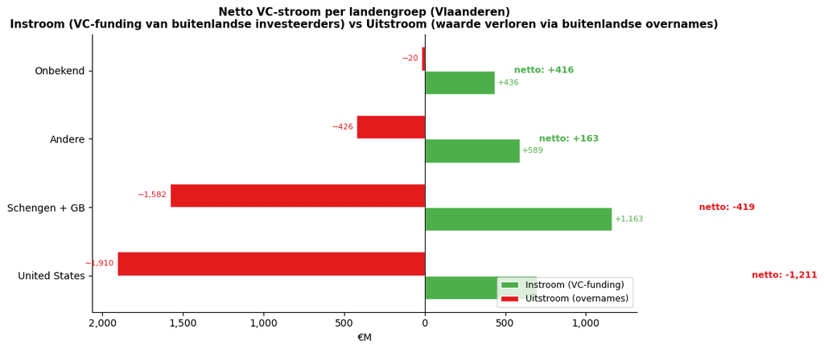

### Fase 6 — Interpretatie: Netto VC-stromen

**Methodologie**:

- **Instroom**: 832 unieke VC-rondes (Dealroom, 2014–2026) van Belgische startups, €4,9 mld totaal. Rondebedrag pro-rata verdeeld over investeerders op basis van `Investors_HQ_location`.
- **Uitstroom**: geschatte overnamewaarde uit Tabel 1 (104 exits met waarde-indicatie, na 7 multiple overrides + 7 LLM-patches). Alleen buitenlandse kopers = outflow.
- **Netto**: instroom − uitstroom per landengroep.

#### Netto VC-stroom per landengroep

| Landengroep | VC-instroom €M | Overname-uitstroom €M | **Netto €M** | Richting |
| --- | --- | --- | --- | --- |
| **United States** | 699 | 1.910 | **−1.211** | ⚠️ Netto uitstroom |
| **Schengen + GB** | 1.163 | 1.582 | **−419** | ⚠️ Netto uitstroom |
| Andere | 589 | 426 | **+163** | ✅ Netto instroom |
| Onbekend | 436 | 20 | **+416** | ✅ Netto instroom |
| **TOTAAL buitenlands** | **2.887** | **3.938** | **−1.051** | ⚠️ Netto uitstroom |

> Belgisch binnenlands VC: €1.981M (41% van totale VC-funding) — geen outflow want thuisland.

#### Kernbevindingen

1. **Vlaanderen is een netto VC-exporteur** (−€1,1 mld) — consistent met Baarsma (NL: −$89,7 mld). De schaal is ~100× kleiner, maar het patroon is identiek: er stroomt meer waarde uit via overnames dan er binnenkomt via VC.
2. **VS = grootste netto waardelekkage** (−€1,2 mld). Amerikaanse investeerders brengen €699M in, maar VS-kopers nemen €1.910M mee. Ratio **2,7× meer uit dan in**. Dit bevestigt Baarsma’s these voor Vlaanderen.
3. **Schengen+GB = tweede lekkage** (−€419M). Europese buurlanden investeren €1.163M maar nemen €1.582M mee via overnames. Minder extreem dan VS (ratio 1,4×).
4. **Belgisch VC = volumespeler** (€1.981M, 41% van totaal). Belgische fondsen financieren het meest, maar Belgische overnames zijn klein (€419M). Dit is binnenlandse circulatie, geen uitstroom.

#### Vergelijking met Baarsma (NL)

| Dimensie | Baarsma (NL) | Onze analyse (VL) | Verschil |
| --- | --- | --- | --- |
| Netto VC-stroom | **−$89,7 mld** | **−€1,1 mld** | Zelfde richting, ~100× kleiner |
| US instroom (VC) | $14,9 mld (>50% buitenlands) | €699M (24% buitenlands) | VS minder dominant in VL |
| US uitstroom (overnames) | Dominant | €1.910M (49% buitenl. uitstroom) | Consistent |
| Ratio US uit/in | ~9× | **2,7×** | VL minder extreem |
| Europese rol | Beperkt | **Schengen+GB = #1 investor** (€1.163M) | Fundamenteel verschil |

#### Beleidsimplicaties

- **De Baarsma-these klopt voor Vlaanderen**, maar met een Europese nuance: de lekkage gaat niet alleen naar de VS maar ook naar buurlanden.
- **VS-ratio 2,7× is verontrustend**: voor elke €1 die VS-investeerders in Vlaamse startups steken, nemen VS-kopers €2,70 mee. Dit is de “VS-hefboom” die Baarsma beschrijft.
- **Belgisch VC is sterk** (41% van totaal) maar financiert de kleinere startups. De grote exits (€100M+) worden gebouwd met buitenlands VC en vervolgens door buitenlanders overgenomen.
- **Luceda (€41.5M)** is een nieuw voorbeeld van de “Andere”-categorie: Aziatisch kapitaal (Singapore/China) dat Vlaamse halfgeleidertechnologie overneemt — een trend om te monitoren.

# Fase 7 — Synthese: VS Kapitaal in Vlaanderen

> Reproductie van Baarsma & Upis (2025) “Nederlandse groeibedrijven zoeken laatste vijf jaar vaker kapitaal in de VS”, toegepast op het Vlaamse startup-ecosysteem (2014–2026).

## 1. Executive Summary

Vlaanderen is, net als Nederland, een **netto exporteur van startup-waarde** (−€1,1 mld). De Baarsma-these — “buitenlands kapitaal koopt onze startups op” — klopt, maar met een fundamenteel andere dynamiek:

|  | Nederland (Baarsma) | Vlaanderen (deze analyse) |
| --- | --- | --- |
| **Netto uitstroom** | −$89,7 mld | **−€1,1 mld** |
| **Dominante buitenlandse koper** | VS | **VS (waarde) + Schengen+GB (volume)** |
| **VS-aandeel in deals** | ~25–30% | **~14%** |
| **VS-aandeel in waarde** | Dominant | **44%** |
| **PE/VC als kopertype** | ~30–40% | **2%** |
| **Belangrijkste verschil** | VS domineert op alle dimensies | Gesplitst: VS = waarde, Europa = volume |

**Kernbevinding**: In Vlaanderen is het verhaal genuanceerder dan in Nederland. De VS koopt minder vaak (~14% van deals) maar neemt wél de duurste bedrijven mee (44% van waarde). Europese buurlanden (Schengen+GB) domineren in aantallen (23–34% van deals) maar zijn minder agressief in waarde per deal.

## 2. Bevindingen per deliverable

### Figuur 1 — Overnames per land van koper

- **164 exits** (View A), **200 events** incl. 36 Sequenza-only GUO-switches (View B)
- België = 55% van exits, VS = 14%, Schengen+GB = 23%
- Versnelling vanaf 2020 consistent met NL-patroon, piek in 2024
- View B versterkt het Europese patroon: stille overnames zijn bijna allemaal Schengen-landen

### Tabel 1 — Top deals & waardestroom

- **104/161 exits (65%) met waarde-indicatie** via 4-proxy pipeline + 7 LLM-patches
- 7 firm-level multiple overrides na expert review (IT services ≠ SaaS)
- 3 exclusies (RESPONSUM = VC-ronde, Aloxy = investeerder niet koper, Agomab 2021 = omgekeerde richting)
- Geschat totaal: **~€4,4 mld** (na correcties)
- VS = 44% van waarde (€1.910M), Schengen+GB = 36% (€1.582M)
- **Waarde-paradox**: België doet het meeste deals maar vangt slechts 10% van de waarde

### Kern — Netto VC-stromen (Baarsma-reproductie)

- Buitenlandse VC-instroom: **€2.887M** | Overname-uitstroom: **€3.938M** | **Netto: −€1.051M**
- VS-hefboom: **2,7×** (voor elke €1 VC-instroom, €2,70 uitstroom via overnames)
- Schengen+GB-ratio: **1,4×**
- Belgisch VC = 41% van totale instroom maar financiert kleinere startups

## 3. Methodologische noot

### Multi-bron aanpak als Mergermarket-alternatief

Baarsma gebruikt Mergermarket (niet beschikbaar voor VLAIO). Wij gebruiken een **multi-bron architectuur**:

[output not shown]

**Voordelen**: reproduceerbaar binnen VLAIO-dataplatform, geen Mergermarket-licentie nodig, multi-bron verhoogt dekking.  
**Beperkingen**: proxy-waarden (Cat 2–3) zijn schattingen, 57/161 exits (35%) zonder waarde-indicatie, LLM-waarden niet onafhankelijk geverifieerd.

## 4. Beleidsaanbevelingen

1. **VS-hefboom aanpakken**: ratio 2,7× toont dat VS-kopers disproportioneel profiteren van Vlaamse startups. Retentie-instrumenten overwegen (bv. belastingvoordelen bij langer aanhouden, golden shares bij publiek gefinancierde startups).
2. **Europees patroon benutten**: Schengen+GB = #1 buitenlandse koper in aantallen. Europese integratie is een kans — Vlaamse startups schalen vaak via Europese overnames. Beleid kan dit kanaliseren.
3. **Waarde-paradox adresseren**: België doet het meeste deals maar vangt slechts 10% van de waarde. Belgische kopers nemen kleinere startups over. Corporate venturing / scale-up programma’s kunnen Belgische bedrijven helpen om grotere deals te doen.
4. **Structureel dashboard**: deze analyse is een nulmeting. Kwartaalupdates met Dealroom + Sequenza + NBB data zijn haalbaar binnen het VLAIO-dataplatform.